# estimators_and_data_exploration slides

Estimators and data exploration

$\def\E{\operatorname{E}}$ $\def\Var{\operatorname{Var}}$ $\def\Cov{\operatorname{Cov}}$ $\def\dd{\mathrm{d}}$ $\def\ee{\mathrm{e}}$ $\def\Norm{\mathcal{N}}$ $\def\Uniform{\mathcal{U}}$

$$\def\E{\operatorname{E}}$$ $$\def\Var{\operatorname{Var}}$$ $$\def\Cov{\operatorname{Cov}}$$ $$\def\dd{\mathrm{d}}$$ $$\def\ee{\mathrm{e}}$$ $$\def\Norm{\mathcal{N}}$$ $$\def\Uniform{\mathcal{U}}$$

## Statistics and estimators

A statistic is a function of a sample of RVs.

An *estimator* is a statistic that estimates a parameter of the population distribution that the samples are drawn from.

An estimator for population parameter $\theta$ is usually written with a hat: $\hat \theta (X_1,\dots,X_n)$, for sample $X_1,\dots,X_n$.

For example:

- Sample mean:
  - $\hat\mu = \bar X = \frac{1}{n}\sum_{i=1}^n X_i$
- Sample variance:
  - $\hat\sigma^2 = s^2 = \frac{1}{n-1}\sum_{i=1}^n (X_i-\bar X)^2$

### Bias

An estimator is unbiased if its expectation agrees with the population parameter: $$ \E[\hat\theta] = \theta $$

For example, the sample mean:

$$ \E[\bar X] = \E[\frac{1}{n}\sum_i X_i] = \frac{1}{n}\sum_i\int x_i p_{X_i}(x_i)\dd x_i $$

If the $X_i$ are all from the same distribution $p_{X_i}(x_i) = p_{X}(x)$ then

$$ \E[\bar X] = \frac{1}{n}\sum_i\int x p_{X}(x)\dd x = \int x p_{X}(x)\dd x = \mu $$ So the sample mean is an unbiased estimator of the population mean.

### Variance

Another property of an estimator is its variance. For the sample mean:

\begin{align*} \Var[\bar X] &= \E[\bar X^2] - \E[\bar X]^2 = \frac{1}{n^2}\sum_{ij}\E[X_i X_j] - \mu^2 \\ &= \frac{1}{n^2}\sum_{i=j}\E[X_i X_j] + \frac{1}{n^2}\sum_{i\neq j}\E[X_i X_j] - \mu^2 \\ \end{align*}

If the $X_i$ are iid, then $\E[X_i X_j] = \E[X_i]\E[X_j] = \mu^2$ and \begin{align*} \Var[\bar X] &= \frac{1}{n^2}\sum_{i=j}\E[X_i X_j] + \frac{n^2 - n}{n^2}\mu^2 - \mu^2 \\ &= \frac{1}{n}\left(\E[X_1^2] - \mu^2\right) = \frac{1}{n}\sigma^2 \end{align*}

The variance of the mean therefore decreases as $\frac{1}{n}$ and the standard deviation as $\frac{1}{\sqrt{n}}$.

Note that for dependent $X_1,\dots,X_n$ this is not the case (generally, not just for Gaussian distributed $X_i$): \begin{equation} \begin{split} \Var[\bar X] &= \Var[\frac{1}{n}\sum X_i] = \frac{1}{n^2}\sum_{i}\Var[X_i] + \frac{1}{n^2}\sum_{i\neq j}\Cov[X_i, X_j] \\ & = \frac{1}{n}\Var[X_1] + \frac{2}{n^2}\sum_{i>j}\Cov[X_i, X_j] \end{split} \end{equation}

### Clicker

Why does the estimator for the sample variance $\hat\sigma^2 = \frac{1}{n-1}\sum_{i=1}^n (X_i-\bar X)^2$ use the prefactor $\frac{1}{n-1}$ instead of $\frac{1}{n}$?

Because we calculate the residuals $X_i - \bar X$ with respect to the sample mean, this minimises the sum of squares and underestimates the variance if we use the $\frac{1}{n}$ factor.

One way to see this is to note that the $n$ residuals $X_i - \bar X$ are not independent.

Given $n-1$ of the $X_i$ and the sample mean $\bar X$, we know what $X_n$ is.

Formally, we can also show this with some matrix algebra. Write the mean as $$ \bar X = \frac{1}{n}\sum_i X_i = \frac{1}{n}\vec{𝟙}^T \vec X, \quad \vec{𝟙} = (1,\dots, 1)\,. $$

The residuals can now be written as $$ \vec X - \bar X = (𝟙 - \frac{1}{n}\vec{𝟙}\vec{𝟙}^T)\vec X, \quad 𝟙 = \begin{pmatrix} 1 & & \\ & \ddots & \\ & & 1 \end{pmatrix}\,. $$

Now we note that (hint, using the matrix determinant lemma $\det{(A + \vec u{\vec v}^T)} = (1 + \vec{v}^T A^{-1}\vec{u})\det A$) $$ \mathrm{rank}(𝟙 - \frac{1}{n}\vec{𝟙}\vec{𝟙}^T) = n - 1\,, $$ that is, there are only $n-1$ independent rows in $(𝟙 - \frac{1}{n}\vec{𝟙}\vec{𝟙}^T)$.

## Sampling distributions

In a Bayesian analysis, we need to know the likelihood of the data: the conditional probability of the observed data, given the parameters: $p(d | \theta)$.

If we compress the data $d$ using a statistic $\hat S = S(d)$, we therefore need to know the distribution of the statistic: $p(\hat S | \theta)$.

Even if the underlying data are normally distributed and the statistic is a simple function, the resulting distribution can become quite complicated.

We can often appeal to the central limit theorem and assume that our statistic is approximately Gaussian distributed but this assumption should be carefully checked, especially when the averaging happens over low number of data.

#### Sample mean:

- For $n$ iid $\vec X_i\sim\Norm(\vec\mu,\Sigma)$, the sample mean is also Gaussian distributed: $\hat{\vec\mu}\sim\Norm(\vec\mu, \frac{1}{n}\Sigma)$.

#### Sample variance

$$ \hat\sigma^2 = s^2 = \frac{1}{n-1}\sum_{i=1}^n (X_i-\bar X)^2 $$

If the statistic you use for your analysis is the sample variance, you probably need to use a Gamma distribution for your likelihood.

#### Example: angular power spectra

The cosmic microwave background as observed by the Planck satellite:

[figure not shown]

The cosmic microwave background (CMB) is the left-over radiation from when the Universe was about 300k years old. It is an almost perfect blackbody, with a temperature of 2.725 K today. It is the same in all directions, with only very small ($\mathcal{O}(10^{-5})$) perturbations.

The perturbations form a Gaussian random field. A Gaussian random field is a generalisation of multivariate Gaussians to functions: any set of points is jointly Gaussian distributed. This is also called a Gaussian process.

The Gaussian random field is completly characterised by its covariance function and mean. In cosmology, the mean is zero.

A scalar field $T$ on the sphere can be decomposed into spherical harmonic coefficients $a_{\ell m} = \int Y_{\ell m}(\vec\vartheta)T(\vec\vartheta)\dd^2\vartheta$.

If T is a Gaussian random field, these are independently Gaussian distributed $$ \Re(a_{\ell m}), \Im(a_{\ell m}) \sim \Norm(0, \frac{C_\ell}{2})\,. $$ Assuming isotropy (there is no preferred direction), the angular power spectrum $C_\ell$ is defined as $$ \E[a_{\ell m}a_{\ell' m'}^*]=\delta_{\ell\ell'}\delta_{mm'}C_\ell \,. $$

[figure not shown]

Because the mean is zero, the angular power spectrum $C_\ell$ captures all the information of the perturbations of the CMB. This makes it a good statistic to use.

The estimator for the angular power spectrum is $$ \hat C_\ell = \frac{1}{2\ell + 1}\sum_{m=-\ell}^\ell a_{\ell m}^* a_{\ell m}\,. $$

From this follows that $$ \hat C_\ell \sim \mathrm{Gamma}\left( \frac{2\ell+1}{2}, \frac{2C_\ell}{2\ell+1}\right)\,. $$

For low $\ell$, this distribution is not Gaussian and the likelihood needs to take this into account.

### Covariance

The multivariate generalisation of the sample variance is the sample covariance. For $n$ vector RV $\vec X_i$, $i=1,\dots,n$, the sample covariance matrix is $$ \hat\Sigma = \frac{1}{n-1}\sum_i^n (\vec X_i - \bar{\vec X})(\vec X_i - \bar{\vec X})^T $$

If $\vec X_i$ are Gaussian distributed, $\vec X_i\sim\Norm(\mu,\Sigma)$, the sample covariance is Wishart distributed. $$ \hat\Sigma \sim \mathcal{W}_p(\frac{1}{\nu}\Sigma, \nu)\ , $$ where $p$ is the size of the data vector and the number of degrees of freedom $\nu$ is $\nu = n-1$.

The Wishart distribution is a matrix distribution, that is it assigns probabilities to matrices. It is a multivariate generalisation of the Gamma distribution.

#### Example: Bias of the inverse of the sample covariance

We are often in the situation where we estimate the covariance from a sample but what we actually care about is the the inverse to compute likelihoods.

If $\hat \Sigma$ is Wishart distributed, then $\hat \Sigma^{-1}$ is inverse Wishart distributed: $$ \hat \Sigma^{-1} \sim \mathcal{W}^{-1}_p(\nu\Sigma^{-1}, \nu) $$

Note that $\hat \Sigma^{-1}$ is a biased estimator of the precision matrix $\Sigma^{-1}$: $$ \E[\hat \Sigma^{-1}] = \frac{\nu}{\nu - p - 1}\Sigma^{-1} = \frac{n - 1}{n - p - 2}\Sigma^{-1} $$

An unbiased estimate of the inverse of the covariance is therefore $\frac{n - p - 2}{n-1} \hat \Sigma^{-1}$.

The factor $\frac{n - 1}{n - p - 2}$ is sometimes known as the Hartlap factor in cosmology but it is just a consequence of the inverse Wishart distribution.

A cleaner treatment is to marginalise the likelihood over the distribution of the (unknown) true covariance (see [Selletin et al. 2016](http://adsabs.harvard.edu/abs/2016MNRAS.456L.132S))

## Correlation

If we know little about the data, looking for correlations is often a good start. The Pearson correlation coefficient is defined as $$ \rho_{X,Y} = \frac{\Cov[X, Y]}{\sigma_X \sigma_Y}\ . $$ It takes values between -1 and 1, with 0 being no correlation.

An estimator for the correlation is: $$ \hat r = \frac{\sum_i(X_i - \bar X)(Y_i - \bar Y)}{\sqrt{\sum_i(X_i - \bar X)^2}\sqrt{\sum_i (Y_i - \bar Y)^2}}\,. $$

### Clicker

If two random variables X and Y have zero correlation, what does this imply about their relationship?

- X and Y are independent.
- X and Y must have a correlation coefficient of 1.
- X and Y have no relationship at all.
- X and Y have no linear relationship but may still be dependent.

Except for jointly Gaussian distributed RVs, lack of correlation does not mean lack of dependence!

[figure not shown]

by Denis Boigelot

If there is a non-linear relationship between the RVs, the correlation can also be a very insufficient statistic, as illustrated by Anscombe's quartet: all entries have the same mean, variance, and correlation

[figure not shown]

The distribution of the Pearson correlation coefficient is slightly complicated, involving hypergeometric functions. But we can implement it:

```python
def pearson_r(x, y, axis=0):
    """Compute the Pearson correlation coefficient."""
    x_ = x - np.mean(x, axis=axis, keepdims=True)
    y_ = y - np.mean(y, axis=axis, keepdims=True)

    r = np.sum(x_*y_, axis=axis) / (np.sqrt(np.sum(x_**2, axis=axis))*np.sqrt(np.sum(y_**2, axis=axis)))
    return r

def pearson_r_pdf(r, n, rho):
    """Compute the PDF of the Pearson correlation coefficient."""
    # https://mathworld.wolfram.com/CorrelationCoefficientBivariateNormalDistribution.html
    hypergeom = scipy.special.hyp2f1(0.5, 0.5, (2*n-1)/2, (rho*r+1)/2)
    Gamma = scipy.special.gamma
    return (
        (n-2)*Gamma(n-1)*(1-rho**2)**((n-1)/2)*(1-r**2)**((n-4)/2)
        / (np.sqrt(2*np.pi)*Gamma(n-0.5)*(1-rho*r)**(n-3/2))
        * hypergeom
    )
```

To check if the PDF is implemented correctly, let us simulate a large number of iid bivariate normal RVs and compare the histogram of the estimated Pearson correlation coefficient to the analytic PDF.

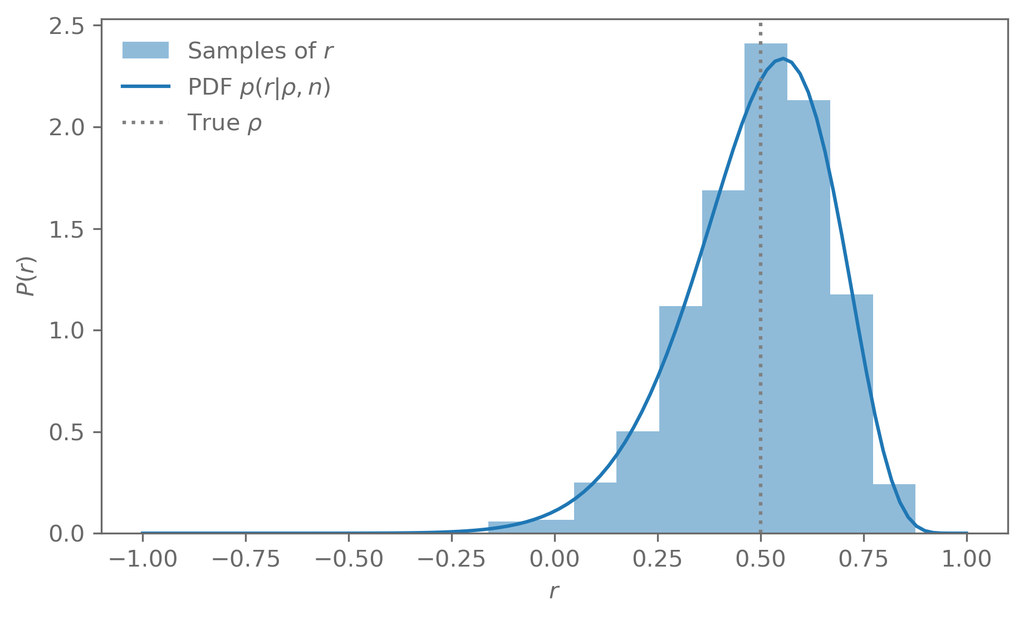

## Malmquist bias

Imagine you measure the (intrinsic) luminosities and distances of a sample of galaxies. The plot might look something like this:

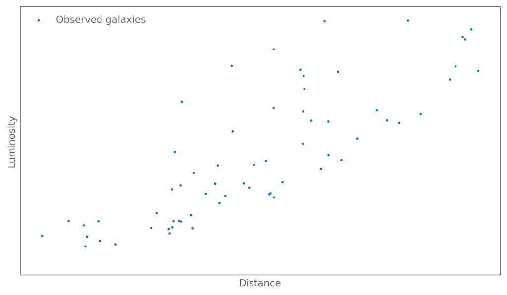

Is there a correlation of galaxy luminosity with distance?

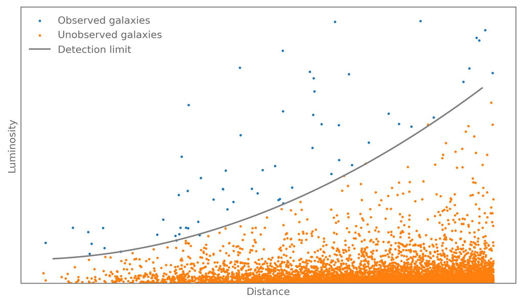

Be wary of selection effects!

Power-law distributions are common in the physical sciences but they can behave in unintuitive ways.

## Exercise

Show that the sample variance $s^2 = \frac{1}{n-1}\sum_{i=1}^n (X_i-\bar X)^2$ is an unbiased estimator of the population variance.

Where does the factor of $\frac{1}{n-1}$ come from? What is the unbiased estimator of the population variance if the population mean $\mu$ is known?

Make a toy data set by sampling from a bivariate Gaussian. Compute the posterior of the correlation coefficient $\rho$, given the observed $\hat r$.

# Data exploration

## PCA

Principal component analysis (PCA) is useful when the data has many dimensions and we want to know which of the dimensions are important, in the sense that we can reproduce the salient features of the data with a smaller number of dimensions.

We start with $n$ observations $\vec X_i$, $i=1,\dots,n$ with $d$ features, that we arrange in a $n\times d$ matrix $X_{ij}$.

1. Remove the mean of the observations from each row $Y_{ij} = X_{ij} - \frac{1}{n}\sum_k X_{kj}$
2. Take the covariance $C = Y^T Y$
3. Find the eigenvalues $\lambda_i$ and eigenvectors $\vec E_j$ of the covariance $C$
4. Sort the eigenvalues by descending order, sort the eigenvectors the same way, and arrange the eigenvectors as columns in a matrix $E$
5. Project the data onto the principal components (the eigenvectors) to get the principal component coefficients $T = Y E$
6. Optionally project back into data-space, using only a small number of coefficients

To illustrate, we look at data from a bivariate Gaussian distribution, so the number of data dimensions is $d = 2$.

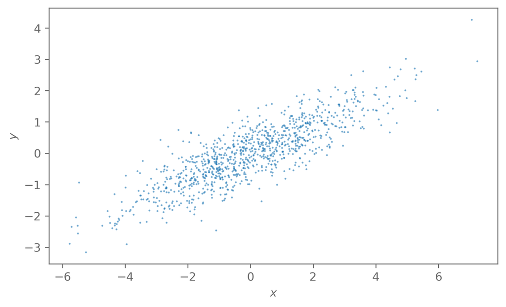

```python
def PCA(data):
    # Remove the mean
    data_mean = data.mean(axis=1)[:, None]
    X = data - data_mean
    # Get covariance and its eigenvectors
    cov_X = np.cov(X)
    l, E = np.linalg.eigh(cov_X)

    # Sort by the eigenvalues
    sort_idx = np.argsort(l)[::-1]
    l = l[sort_idx]
    E = E[:,sort_idx]

    def project_onto_pc(d):
        if d.ndim == 1:
            d = d[:, np.newaxis]
        return E.T @ (d - data_mean)

    def reconstruct_from_pc(c):
        if c.ndim == 1:
            c = c[:, np.newaxis]
        return E[:, :c.shape[0]] @ c + data_mean

    return l, E, project_onto_pc, reconstruct_from_pc

l, E, project_onto_pc, reconstruct_from_pc = PCA(samples.T)
```

The first principal component describes most of the variance of the data. In other words, we were to reconstruct the data with just the first component, we would already capture most of the features of the distribution of the data.

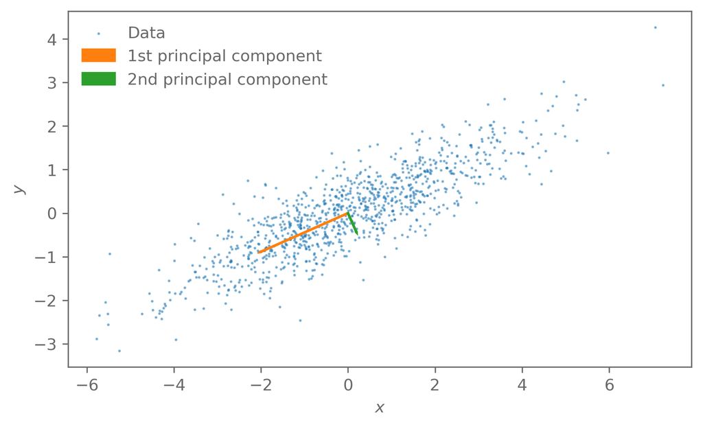

For Gaussian data, the principal components capture all the information about the distribution.

For non-Gaussian data that is not the case but PCA might still be useful for finding informative subspaces.

### Clicker

If you have a dataset where the first two principal components account for 95% of the variance, what can you infer about the dataset's structure, assuming it is Gaussian?

- The original features are highly independent, so reducing dimensionality will lose essential information.
- The data points are distributed uniformly across all dimensions.
- The data has a strong structure in one or two dimensions, allowing reduction to two dimensions without major information loss.
- The eigenvalues associated with other dimensions must be nearly as large as the first two.

#### Example: matter power spectra

Because the Universe started out as a Gaussian random field, it is common to analyse data in cosmology using power spectra.

Similar to the case of the CMB, for an isotropic 3D field $\delta(\vec x)$ with Fourier transform $\delta(\vec k)$, the power spectrum is defined as $$ \E[\delta(\vec k)\delta^*(\vec k)] \propto P(|\vec k|)\,. $$ This can be understood as the variance of the field at wave-number $k$. Or more informally, how clumpy is the field on a specific scale.

In this example, we look at the power spectra of some of the state-of-the-art simulations of the Universe.

[figure not shown]

Depending on how galaxy formation is modelled in these simulations, the power spectrum of the matter distribution changes. Here we look at the ratio between the matter power spectrum of a simulation that models galaxy formation and one where there is only dark matter.

In `data/Pk_lib/power_spectrum_suppression.txt` are a list of ratios of matter power spectra from hydrodynamical simulations and the same simulations but assuming all matter is dark matter.

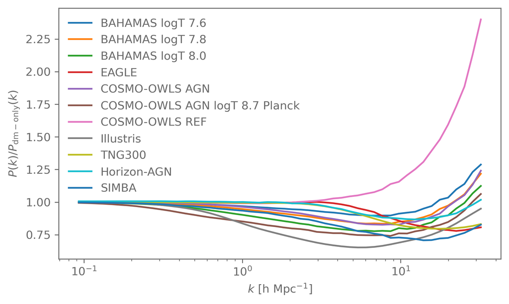

```python
l, E, project_onto_pc, reconstruct_from_pc = PCA(power_spectra)
```

Check the eigenvalues:

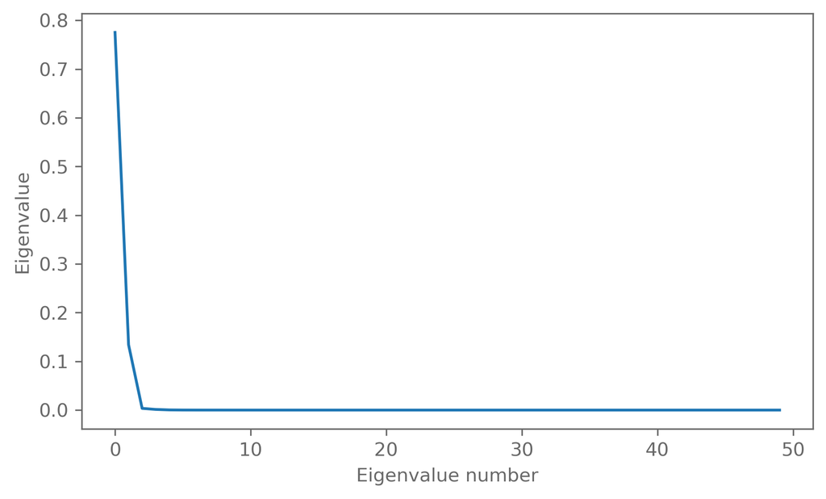

What are the principal components that the data are projected onto (show in data space here)?

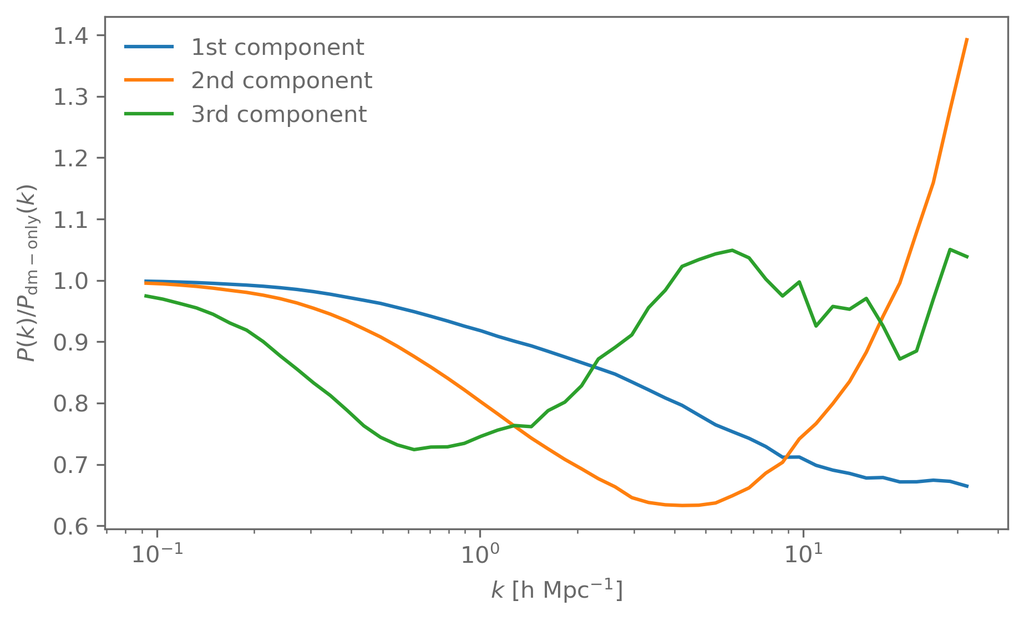

Project back into data space with only a few components.

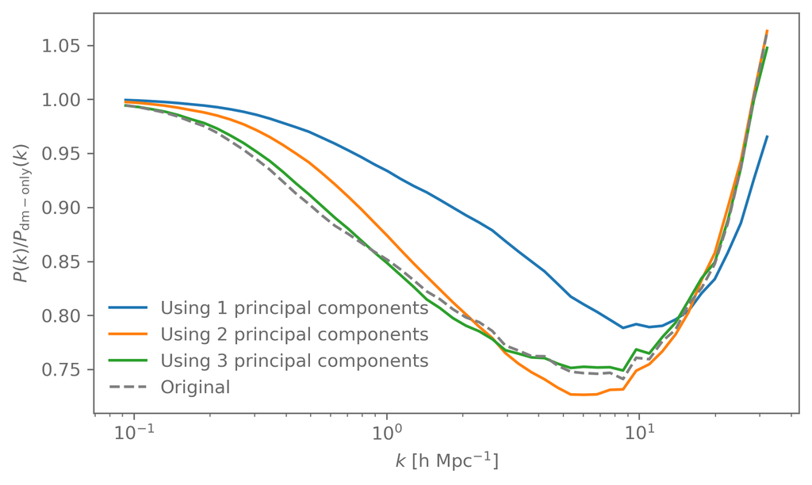

## Bootstrap

We are often in the situation where we have data but do not know the distribution of the statistics of the data.

Here the [bootstrap](http://dx.doi.org/10.1214/aos/1176344552) comes in handy, as it allows us to approximate the sampling distribution of our statistic from the sample:

Assume we have $n$ iid data $X_i$, and a statistic $\phi$.

We can calculate the value of the statistic on the sample $\hat f = \phi(X_1,\dots,X_n)$.

What we want to know is the sampling distribution of $\phi$, i.e., what values $\hat f$ would take if we were to sample new $X_i$ from the true distribution of $X$.

If the $X_i$ are not Gaussian distributed and $\phi$ is non-linear, this can be very difficult to do analytically.

Here the bootstrap comes in handy:

1. Sample with replacement $n$ times from the $n$ samples $X_i$. Let us call these $Y_i$
2. Compute the statistic using the resampled data: $\hat f^* = \phi(Y_1,\dots,Y_n)$
3. Repeat steps 1) and 2) $N$ times ($N$ being large), recording the values of $\hat f^*_j$, $j=1,\dots,N$

The distribution of $\hat f^*_j$ approximates the true sampling distribution of $\hat f$.

This is a pretty amazing result. Because we seem to get something (the sampling distribution) from nothing (just the one realisation of the samples), this is called the bootstrap.

In its basic form it assumes independent data, extensions to dependent data do exist and usually revolve around resampling blocks of the data that are approximately independent.

```python
def bootstrap(data, statistic, n_trial):
    n_data = data.shape[1]
    s = []
    for i in range(n_trial):
        idx = np.random.choice(n_data, size=n_data, replace=True)
        data_resampled = data[:, idx]
        s.append(statistic(data_resampled))

    return np.array(s)
```

Let us apply the bootstrap to find the distribution of the PCA coefficients of the power spectrum example from earlier:

```python
def PCA_coefficients(data, data_point):
    l, E, project_onto_pc, reconstruct_from_pc = PCA(data)
    coefficients = project_onto_pc(data_point)
    return coefficients

coefficient_samples = bootstrap(
    power_spectra,
    statistic=lambda data: PCA_coefficients(
        data, data_point=data_point),
    n_trial=1000
)
```

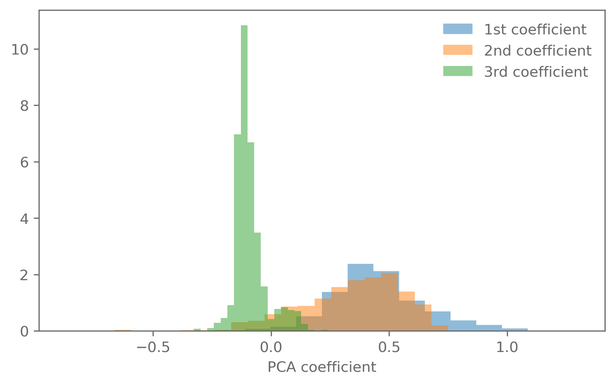

We can also use the bootstrap to estimate the uncertainty of a reconstructed power spectrum.

```python
def PCA_and_reconstruct(data, data_point, n_component):
    l, E, project_onto_pc, reconstruct_from_pc = PCA(data)
    coefficients = project_onto_pc(data_point)
    return reconstruct_from_pc(coefficients[:n_component])

data_point = power_spectra[:, 5]
l, E, project_onto_pc, reconstruct_from_pc = PCA(power_spectra)
coefficients = project_onto_pc(data_point)
reconstructed = reconstruct_from_pc(coefficients[:3])

reconstructed_samples = bootstrap(
    power_spectra,
    statistic=lambda data: PCA_and_reconstruct(
        data, data_point=data_point, n_component=3),
    n_trial=200
)
```

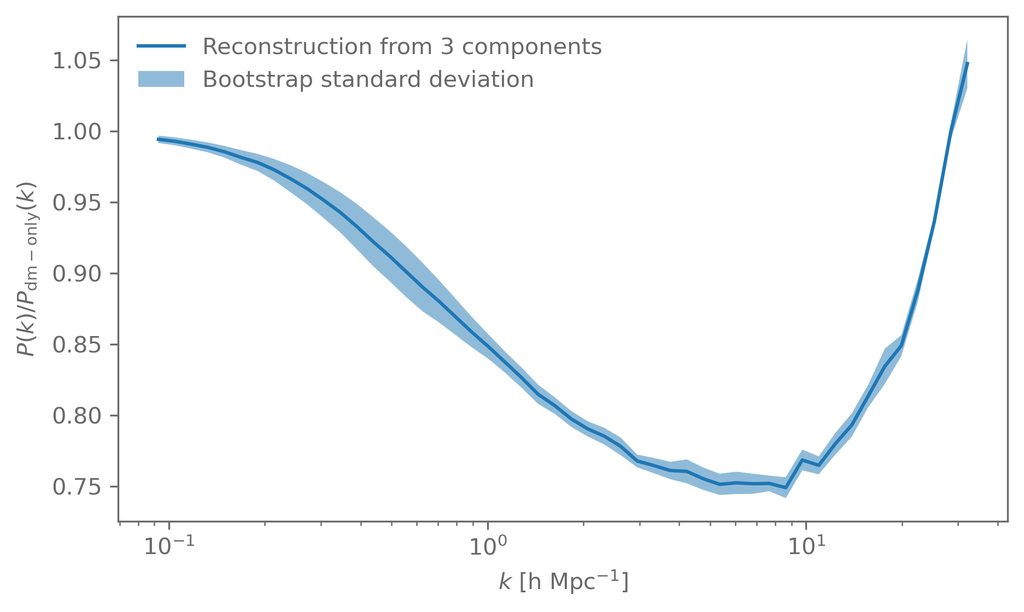

### Clicker

Why might bootstrapping fail to approximate the sampling distribution?

- Resampling the data might introduce artificial artifacts by overfitting.
- The bootstrap requires an infinite sample size to correct for dependencies.
- Bootstrap resampling increases bias in the original estimator, compounding dependencies.
- The bootstrap relies on independent observations to ensure that each sample approximates the population, hence it might fail if the data are not i.i.d.

## Exercise

Check that the boostrap works for a case where we do know the sampling distribution. For example the estimators discussed at the beginning of this lecture.